# TAE - Unit 4 - Lecture 1

GT

May 9, 2016

## Judge, Jury and Classifier

In this lecture, we’ll see how analytics can be used to predict the outcomes of cases in the United States Supreme Court.

This seems like a very unconventional use of analytics, but in 2002 a group of political science and law academics decided to test if a model can do better than a group of experts at predicting the decisions of the Supreme Court.

In this case, a very interpretable analytics method was used, called classification and regression trees.

The legal system of the United States operates at the state level and at the federal or country-wide level. The federal level is necessary to deal with cases beyond the scope of state law, like disputes between states, and violations of federal laws.

The federal court is divided into three levels

- District courts
- Circuit courts
- Supreme Court.

Cases start at the district courts, where an initial decision is made about the case. The circuit courts hear appeals from the district courts, and can change the decision that was made. The Supreme Court is the highest level in the American legal system and makes the final decision on cases.

The Supreme Court of the United States consists of nine judges, or justices, who are appointed by the President.

The people appointed as Supreme Court justices are usually distinguished judges, professors of law, or state or federal attorneys. The Supreme Court of the United States, or SCOTUS, decides on the most difficult and controversial cases in the United States.

These cases often involve an interpretation of the Constitution, and have significant social, political, and economic consequences.

Since non-profits, voters, and anybody interested in long-term planning can benefit from knowing the outcomes of the Supreme Court cases before they happen, legal academics and political scientists regularly make predictions of Supreme Court decisions from detailed studies of the cases and individual justices.

In 2002, Andrew Martin, a professor of political science at Washington University in St. Louis, decided to instead predict decisions using a statistical model built from data. Together with his colleagues, he decided to test the model against a panel of experts. They wanted to see if an analytical model could outperform the expertise and intuition of a large group of experts.

Martin used a method called *classification and regression trees*, or **CART**.

In this case, the outcome is binary. Will the Supreme Court affirm the case or reject the case?

He could have used logistic regression for this, but logistic regression models are not easily interpretable. The model coefficients in logistic regression indicate the importance and relative effect of variables, but do not give a simple explanation of how a decision is made.

### CART

To predict the outcomes of the Supreme Court, Martin used cases from 1994 through 2001.

The Supreme Court was composed of the same nine justices that were justices when he made his predictions in 2002.

These nine justices were Breyer, Ginsburg, Kennedy, O’Connor, Rehnquist (Chief Justice), Scalia, Souter, Stevens, and Thomas.

This was a very rare data set, since this was the longest period of time with the same set of justices in over 180 years. This allowed Martin to use a larger data set then might have been available if he was doing this experiment at a different time.

We’ll focus on predicting Justice Stevens’s decisions.

**Dependent variable**: Did Justice Stevens voted to reverse the lower court decision? 1 = reverse, 0 = affirm

**Independent variables**: Properties of the case.

- *Circuit court of origin* is the circuit or lower court where the case came from. There are 13 different circuit courts in the United States. The 1st through 11th and Washington, DC courts are defined by region. And the federal court is defined by the subject matter of the case.
- *Issue area of the case* gives each case a category (civil rights or federal taxation).
- *Type of petitioner* and *type of respondent* define two parties in the case (US, employer or employee).
- *Ideological direction of the lower court decision* (liberal or a conservative).
- *Whether or not the petitioner argued that a law or practice was unconstitutional*.

To collect this data, Martin and his colleagues read through all of the cases and coded the information. Some of it, like the circuit court, is straightforward. But other information required a judgment call, like the ideological direction of the lower court.

Now that we have our data and variables, we are ready to predict the decisions of Justice Stevens.

We can use logistic regression, and we get a model where some of the most significant variables are:

- whether or not the case is from the 2nd circuit court, with a coefficient of 1.66;
- whether or not the case is from the 4th circuit court, with a coefficient of 2.82;
- whether or not the lower court decision was liberal, with a coefficient of negative 1.22.

While this tells us that the case being from the 2nd or 4th circuit courts is predictive of Justice Stevens reversing the case, and the lower court decision being liberal is predictive of Justice Stevens affirming the case, it’s difficult to understand which factors are more important due to things like the scales of the variables, and the possibility of multicollinearity. It’s also difficult to quickly evaluate what the prediction would be for a new case.

So instead of logistic regression, Martin and his colleagues used a method called *classification and regression trees*, or **CART**.

This method builds what is called a tree by splitting on the values of the independent variables. To predict the outcome for a new observation or case, you can follow the splits in the tree and at the end, you predict the most frequent outcome in the training set that followed the same path.

Some advantages of CART are that it does not assume a linear model, like logistic regression or linear regression, and it’s a very interpretable model.

CART tries to split this data into subsets so that each subset is as pure or homogeneous as possible. The splits that CART would create are shown here. The standard prediction made by a CART model is just the majority in each subset.

If a new observation fell into the subset where the majority of the obs are red, then we would predict red. However, if a new observation fell into the subset where the majority of the obs are gray, we would predict gray.

A CART model is represented by what we call a tree.

```
      X<60
       /\
  yes /  \ no
     /    \
   red    Y<20
           /\
      yes /  \ no
         /    \
       X<85   gray
        /\
   yes /  \ no
      /    \
    red   gray
```

The first split tests whether the variable x is less than 60. If yes, the model says to predict red, and if no, the model moves on to the next split. Then, the second split checks whether or not the variable y is less than 20. If no, the model says to predict gray, but if yes, the model moves n to the next split. The third split checks whether or not the variable x is less than 85. If yes, then the model says to predict red, and if no, the model says to predict gray.

There are a couple things to keep in mind when reading trees.

In this tree, and for the trees we’ll generate in R, a yes response is always to the left and a no response is always to the right.

Also, make sure you always start at the top of the tree. The x less than 85 split only counts for observations for which x is greater than 60 and y is less than 20.

### Splitting and Predictions

We generated a CART tree with three splits, but why not two, or four, or even five?

There are different ways to control how many splits are generated.

One way is by setting a lower bound for the number of data points in each subset.

In R, this is called the `minbucket` parameter, for the minimum number of observations in each bucket or subset. The smaller minbucket is, the more splits will be generated.

But if it’s too small, overfitting will occur. This means that CART will fit the training set almost perfectly. But this is bad because then the model will probably not perform well on test set data or new data.

On the other hand, if the minbucket parameter is too large, the model will be too simple and the accuracy will be poor.

In each subset of a CART tree, we have a bucket of observations, which may contain both possible outcomes.

In the Supreme Court case, we’ll be classifying observations as either affirm or reverse. Instead of just taking the majority outcome to be the prediction, we can compute the percentage of data in a subset of each type of outcome.

Then by varying the threshold value, we can compute an ROC curve and compute an AUC value to evaluate our model.

### CART in R

Let’s start by reading in the data file “stevens.csv”. We’ll call our data frame stevens and use the read.csv function to read in the data file “stevens.csv”. Then let’s take a look at our data using the str function.

```r
stevens = read.csv("stevens.csv")
str(stevens)
```

```
## 'data.frame':    566 obs. of  9 variables:
##  $ Docket    : Factor w/ 566 levels "00-1011","00-1045",..: 63 69 70 145 97 181 242 289 334 436 ...
##  $ Term      : int  1994 1994 1994 1994 1995 1995 1996 1997 1997 1999 ...
##  $ Circuit   : Factor w/ 13 levels "10th","11th",..: 4 11 7 3 9 11 13 11 12 2 ...
##  $ Issue     : Factor w/ 11 levels "Attorneys","CivilRights",..: 5 5 5 5 9 5 5 5 5 3 ...
##  $ Petitioner: Factor w/ 12 levels "AMERICAN.INDIAN",..: 2 2 2 2 2 2 2 2 2 2 ...
##  $ Respondent: Factor w/ 12 levels "AMERICAN.INDIAN",..: 2 2 2 2 2 2 2 2 2 2 ...
##  $ LowerCourt: Factor w/ 2 levels "conser","liberal": 2 2 2 1 1 1 1 1 1 1 ...
##  $ Unconst   : int  0 0 0 0 0 1 0 1 0 0 ...
##  $ Reverse   : int  1 1 1 1 1 0 1 1 1 1 ...
```

We have 566 observations, or Supreme Court cases, and nine different variables.

- *Docket* is just a unique identifier for each case
- *Term* is the year of the case

Then we have our **six independent variables**:

- *Circuit*: the circuit court of origin
- *Issue*: the issue area of the case
- *Petitioner*: the type of petitioner
- *Respondent*: the type of respondent
- *LowerCourt*: the lower court direction
- *Unconst*: whether or not the petitioner argued that a law or practice was unconstitutional.

The last variable is our **dependent variable**:

- *Reverse*: whether or not Justice Stevens voted to reverse the case: 1 for reverse, and 0 for affirm.

Now before building models, we need to split our data into a training set and a testing set. We’ll do this using the sample.split function like we did for logistic regression.

```r
library(caTools)
set.seed(3000)
spl = sample.split(stevens$Reverse, SplitRatio = 0.7)
Train = subset(stevens, spl == TRUE)
Test = subset(stevens, spl == FALSE)
```

Now, we’re ready to build our CART model. First we need to install and load the `rpart` package and the rpart plotting package.

```r
library(rpart)
library(rpart.plot)
```

Now we can create our CART model using the rpart function. We’ll use the rpart function, where the first argument is the same as if we were building a linear or logistic regression model. We’ll give two additional arguments here. The first one is method = “class”. This tells rpart to build a classification tree, instead of a regression tree. The last argument we’ll give is minbucket = 25. This limits the tree so that it doesn’t overfit to our training set. Let’s plot our tree using the prp function, where the only argument is the name of our model, StevensTree.

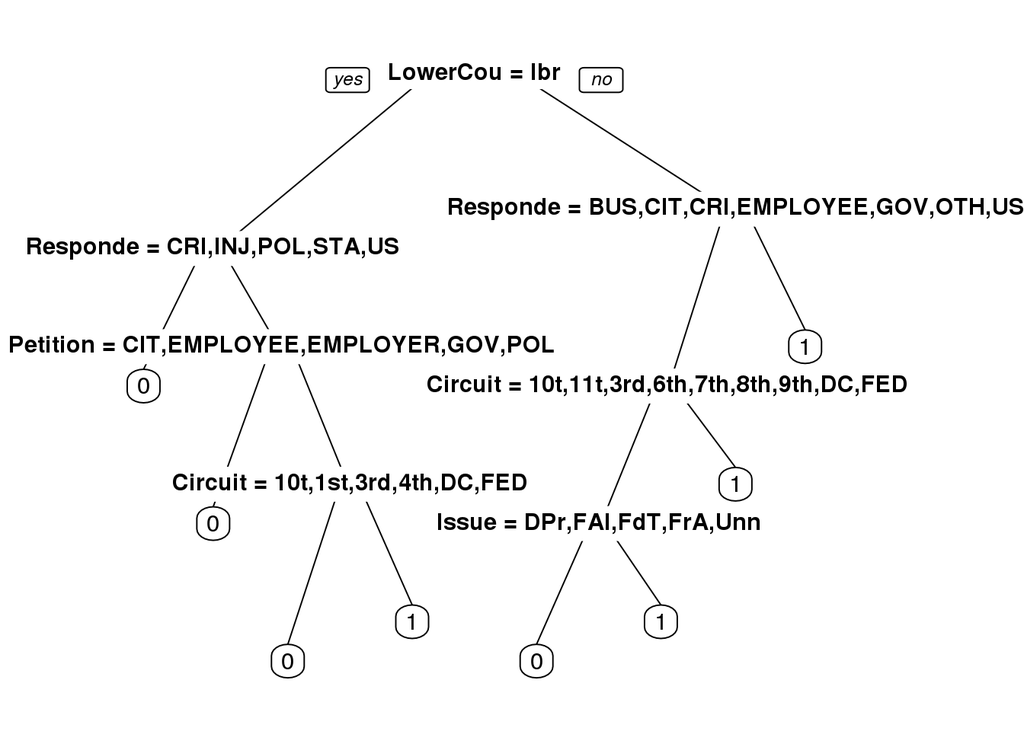

```r
StevensTree = rpart(Reverse ~ Circuit + Issue + Petitioner + Respondent + LowerCourt + Unconst, data = Train, method="class", minbucket=25)
prp(StevensTree)
```

The first split of our tree is whether or not the lower court decision is liberal. If it is, then we move to the left in the tree. And we check the respondent. If the respondent is a criminal defendant, injured person, politician, state, or the United States, we predict 0, or affirm.

You can see here that the prp function abbreviates the values of the independent variables. If you’re not sure what the abbreviations are, you could create a table of the variable to see all of the possible values.

So now moving on in our tree, if the respondent is not one of these types, we move on to the next split, and we check the petitioner. If the petitioner is a city, employee, employer, government official, or politician, then we predict 0, or affirm. If not, then we check the circuit court of origin. If it’s the 10th, 1st, 3rd, 4th, DC or Federal Court, then we predict 0. Otherwise, we predict 1, or reverse.

We can repeat this same process on the other side of the tree if the lower court decision is not liberal.

Comparing this to a logistic regression model, we can see that it’s very interpretable. A CART tree is a series of decision rules which can easily be explained.

Now let’s see how well our CART model does at making predictions for the test set. We’ll use the predict function, where the first argument is the name of our model, StevensTree. The second argument is the new data we want to make predictions for, Test. And we’ll add a third argument here, which is type = “class”. This is like using a threshold of 0.5.

```r
PredictCART = predict(StevensTree, newdata = Test, type="class")
# let's compute the accuracy of our model
table(Test$Reverse, PredictCART)
```

```
##    PredictCART
##      0  1
##   0 41 36
##   1 22 71
```

```r
(41+71)/(41+36+22+71)
```

```
## [1] 0.6588235
```

If you were to build a logistic regression model, you would get an accuracy of 0.665 and a baseline model that always predicts Reverse, the most common outcome, has an accuracy of 0.547.

So our CART model significantly beats the baseline and is competitive with logistic regression. It’s also much more interpretable than a logistic regression model would be.

Lastly, to evaluate our model, let’s generate an ROC curve for our CART model using the ROCR package. First, we need to load the package with the library

```r
library(ROCR)
PredictROC = predict(StevensTree, newdata=Test)
PredictROC
```

```
##             0         1
## 1   0.3035714 0.6964286
## 3   0.3035714 0.6964286
## 4   0.4000000 0.6000000
## 6   0.4000000 0.6000000
## 8   0.4000000 0.6000000
## 21  0.3035714 0.6964286
## 32  0.5517241 0.4482759
## 36  0.5517241 0.4482759
## 40  0.3035714 0.6964286
## 42  0.5517241 0.4482759
## 46  0.5517241 0.4482759
## 47  0.4000000 0.6000000
## 53  0.5517241 0.4482759
## 55  0.3035714 0.6964286
```

[output cut: 156 more lines]

For each observation in the test set, it gives two numbers which can be thought of as the probability of outcome 0 and the probability of outcome 1. These numbers give the percentage of training set data in that subset with outcome 0 and the percentage of data in the training set in that subset with outcome 1.

We’ll use the second column as our probabilities to generate an ROC curve. We’ll start by using the prediction function. We’ll call the output pred, and then use prediction, where the first argument is the second column of PredictROC, which we can access with square brackets, and the second argument is the true outcome values, Test$Reverse. Now we need to use the performance function, where the first argument is the outcome of the prediction function, and then the next two arguments are true positive rate and false positive rate, what we want on the x and y-axes of our ROC curve. Then we can just plot our ROC curve by typing plot(perf).

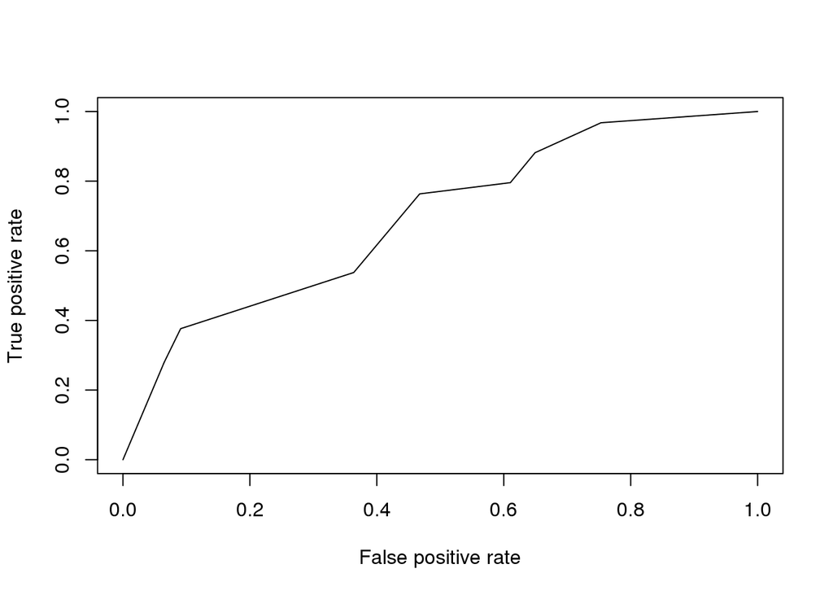

```r
pred = prediction(PredictROC[,2], Test$Reverse)
perf = performance(pred, "tpr", "fpr")
plot(perf)
```

### RandomForest

This method was designed to improve the prediction accuracy of CART and works by building a large number of CART trees. Unfortunately, this makes the method less interpretable than CART, so often you need to decide if you value the interpretability or the increase in accuracy more.

To make a prediction for a new observation, each tree in the forest votes on the outcome and we pick the outcome that receives the majority of the votes.

So how does random forests build many CART trees? We can’t just run CART multiple times because it would create the same tree every time.

To prevent this, random forests only allows each tree to split on a random subset of the available independent variables, and each tree is built from what we call a bagged or bootstrapped sample of the data.

This just means that the data used as the training data for each tree is selected randomly with replacement.

Let’s look at an example. Suppose we have five data points in our training set. We’ll call them 1, 2, 3, 4, and 5. For the first tree, we’ll randomly pick five data points randomly sampled with replacement. So the data could be 2, 4, 5, 2, and 1. Each time we pick one of the five data points regardless of whether or not it’s been selected already. These would be the five data points we would use when constructing the first CART tree.

Then we repeat this process for the second tree. This time the data set might be 3, 5, 1, 5, and 2. And we would use this data when building the second CART tree. Then we would repeat this process for each additional tree we want to create.

So since each tree sees a different set of variables and a different set of data, we get what’s called a forest of many different trees.

Just like CART, random forests has some parameter values that need to be selected.

The first is the minimum number of observations in a subset, or the minbucket parameter from CART. When we create a random forest in R, this will be called nodesize. A smaller value of nodesize, which leads to bigger trees, may take longer in R. Random forests is much more computationally intensive than CART.

The second parameter is the number of trees to build, which is called ntree in R. This should not be set too small, but the larger it is the longer it will take. A couple hundred trees is typically plenty.

A nice thing about random forests is that it’s not as sensitive to the parameter values as CART is.

Let’s switch to R and create a random forest model to predict the decisions of Justice Stevens. In our R console, let’s start by installing and loading the package “randomForest.”

We’ll call it StevensForest and use the randomForest function, first giving our dependent variable, Reverse, followed by a tilde sign, and then our independent variables separated by plus signs. We’ll use the data set Train. For random forests, we need to give two additional arguments. These are nodesize, also known as minbucket for CART, and we’ll set this equal to 25, the same value we used for our CART model. And then we need to set the parameter ntree. This is the number of trees to build. And we’ll build 200 trees here.

```r
library(randomForest)
StevensForest = randomForest(Reverse ~ Circuit + Issue + Petitioner + Respondent + LowerCourt + Unconst, data = Train, nodesize=25, ntree=200)
```

```
## Warning in randomForest.default(m, y, ...): The response has five or fewer
## unique values. Are you sure you want to do regression?
```

You should see an interesting warning message here.

In CART, we added the argument method=“class”, so that it was clear that we’re doing a classification problem. The randomForest function does not have a method argument.

So when we want to do a classification problem, we need to make sure outcome is a factor.

Let’s convert the variable Reverse to a factor variable in both our training and our testing sets.

```r
Train$Reverse = as.factor(Train$Reverse)
Test$Reverse = as.factor(Test$Reverse)
```

Now let’s try creating our random forest again.

```r
StevensForest = randomForest(Reverse ~ Circuit + Issue + Petitioner + Respondent + LowerCourt + Unconst, data = Train, nodesize=25, ntree=200)
```

We didn’t get a warning message this time so our model is ready to make predictions.

Let’s compute predictions on our test set. We’ll call our predictions PredictForest and use the predict function to make predictions using our model, StevensForest, and the new data set Test.

```r
PredictForest = predict(StevensForest, newdata=Test)
table(Test$Reverse, PredictForest)
```

```
##    PredictForest
##      0  1
##   0 41 36
##   1 19 74
```

```r
(41+74)/(41+36+19+74)
```

```
## [1] 0.6764706
```

Our accuracy here is about 67%. Recall that our logistic regression model had an accuracy of 66.5% and our CART model had an accuracy of 65.9%. So our random forest model improved our accuracy a little bit over CART.

Keep in mind that Random Forests has a random component. You may have gotten a different confusion matrix than me because there’s a random component to this method.

### Cross-Validation

In CART, the value of minbucket can affect the model’s out-of-sample accuracy. If minbucket is too small, over-fitting might occur. But if minbucket is too large, the model might be too simple.

So how should we set this parameter value?

We could select the value that gives the best testing set accuracy, but this isn’t right. The idea of the testing set is to measure model performance on data the model has never seen before. By picking the value of minbucket to get the best test set performance, the testing set was implicitly used to generate the model.

Instead, we’ll use a method called **K-fold Cross Validation**, which is one way to properly select the parameter value.

This method works by going through the following steps:

First, we split the training set into k equally sized subsets, or folds. In this example, k equals 5. Then we select k - 1, or four folds, to estimate the model, and compute predictions on the remaining one fold, which is often referred to as the validation set. We build a model and make predictions for each possible parameter value we’re considering.

Then we repeat this for each of the other folds, or pieces of our training set.

So we would build a model using folds 1, 2, 3, and 5 to make predictions on fold 4, and then we would build a model using folds 1, 2, 4, and 5 to make predictions on fold 3, etc.

So ultimately, cross validation builds many models, one for each fold and possible parameter value. Then, for each candidate parameter value, and for each fold, we can compute the accuracy of the model.

Then we plot shows the possible parameter values on the x-axis, and the accuracy of the model on the y-axis, the average the accuracy over the k folds to determine the final parameter value that we want to use.

So far, we’ve used the parameter minbucket to limit our tree in R. When we use cross validation in R, we’ll use a parameter called cp instead. This is the complexity parameter. It’s like Adjusted R-squared for linear regression, and AIC for logistic regression, in that it measures the trade-off between model complexity and accuracy on the training set.

A smaller cp value leads to a bigger tree, so a smaller cp value might over-fit the model to the training set. But a cp value that’s too large might build a model that’s too simple.

Let’s go to R, and use cross validation to select the value of cp for our CART tree.

To do this, we need to install and load two new packages. First, we’ll install and load the package “caret”. Now, let’s install and load the package “e1071”.

```r
library(caret)
library(e1071)
```

Now, we’ll define our cross validation experiment. First, we need to define how many folds we want. We can do this using the trainControl function. we’ll say numFolds = trainControl, and then in parentheses, method = “cv”, for cross validation, and then number = 10, for 10 folds.

```r
numFolds = trainControl(method="cv", number=10)
```

Then we need to pick the possible values for our cp parameter, using the expand.grid function. So we’ll call it cpGrid, and then use expand.grid, where the only argument is .cp = seq(0.01,0.5,0.01). This will define our cp parameters to test as numbers from 0.01 to 0.5, in increments of 0.01.

```r
cpGrid = expand.grid(.cp=seq(0.01, 0.5, 0.01))
```

Now, we’re ready to perform cross validation. We’ll do this using the train function, where the first argument is similar to that when we’re building models. It’s the dependent variable, Reverse, followed by a tilde symbol, and then the independent variables separated by plus signs. Our data set here is Train, with a capital T, and then we need to add the arguments method = “rpart”, since we want to cross validate a CART model, and then trControl = numFolds, the output of our trainControl function, and then tuneGrid = cpGrid, the output of the expand.grid function.

```r
train(Reverse ~ Circuit + Issue + Petitioner + Respondent + LowerCourt + Unconst, data = Train, method="rpart", trControl=numFolds, tuneGrid=cpGrid)
```

```
## CART
##
## 396 samples
##   8 predictors
##   2 classes: '0', '1'
##
## No pre-processing
## Resampling: Cross-Validated (10 fold)
## Summary of sample sizes: 356, 356, 356, 357, 357, 357, ...
## Resampling results across tuning parameters:
##
##   cp    Accuracy   Kappa
##   0.01  0.6340385  0.25243997
##   0.02  0.6186538  0.22035814
##   0.03  0.6135897  0.21530025
##   0.04  0.6314744  0.25684277
##   0.05  0.6441026  0.28527000
##   0.06  0.6441026  0.28527000
##   0.07  0.6441026  0.28527000
##   0.08  0.6441026  0.28527000
##   0.09  0.6441026  0.28527000
##   0.10  0.6441026  0.28527000
##   0.11  0.6441026  0.28527000
##   0.12  0.6441026  0.28527000
##   0.13  0.6441026  0.28527000
##   0.14  0.6441026  0.28527000
##   0.15  0.6441026  0.28527000
##   0.16  0.6441026  0.28527000
##   0.17  0.6441026  0.28527000
##   0.18  0.6441026  0.28527000
##   0.19  0.6441026  0.28527000
##   0.20  0.5882051  0.15017688
##   0.21  0.5607051  0.07616673
##   0.22  0.5504487  0.04838895
##   0.23  0.5454487  0.02838895
##   0.24  0.5428846  0.01714397
##   0.25  0.5453846  0.00000000
##   0.26  0.5453846  0.00000000
##   0.27  0.5453846  0.00000000
##   0.28  0.5453846  0.00000000
```

[output cut: 10 more lines]

[output not shown]

This is the cp value we want to use in our CART model.

So now let’s create a new CART model with this value of cp, instead of the minbucket parameter. We’ll call this model StevensTreeCV,

```r
StevensTreeCV = rpart(Reverse ~ Circuit + Issue + Petitioner + Respondent + LowerCourt + Unconst, data = Train, method="class", cp=0.18)
PredictCV = predict(StevensTreeCV, newdata = Test, type="class")
table(Test$Reverse, PredictCV)
```

```
##    PredictCV
##      0  1
##   0 59 18
##   1 29 64
```

```r
(59+64)/(59+18+29+64)
```

```
## [1] 0.7235294
```

So the accuracy of this model is 0.724. Remember that the accuracy of our previous CART model was 0.659.

Cross validation helps us make sure we’re selecting a good parameter value, and often this will significantly increase the accuracy.

### The Model vs The Experts

So can a CART model actually predict Supreme Court case outcomes better than a group of experts?

Martin and his colleagues used 628 previous Supreme Court cases between 1994 and 2001 to build their model. They made predictions for the 68 cases that would be decided in October, 2002, before the term started.

Their model had two stages of CART trees.

- The first stage involved making predictions using two CART trees. One to predict a unanimous liberal decision and one to predict a unanimous conservative decision. If the trees gave conflicting responses or both predicted no, then they moved on to the next stage.
- The second stage consisted of predicting the decision of each individual justice, and then use the majority decision of all nine justices as a final prediction for the case.

Martin and his colleagues also recruited 83 legal experts, 71 academics, and 12 attorneys. 38 had previously clerked for a Supreme Court Justice, 33 were chaired professors, and five were current or former law school deans. So this was really a dream team of experts.

Additionally, the experts were only asked to predict within their area of expertise. So not all experts predicted all cases, but there was more than one expert making predictions for each case. When making their predictions, the experts were allowed to consider any source of information, but they were not allowed to communicate with each other regarding the predictions.

For predicting the overall decision that was made by the Supreme Court, the models had an accuracy of 75%, while the experts only had an accuracy of 59%.

So the models had a significant edge over the experts in predicting the overall case outcomes.

However, when the predictions were run for individual justices, the model and the experts performed very similarly. For some justices, the model performed better, and for some justices, the experts performed better.

Being able to predict Supreme Court decisions is very valuable to firms, politicians, and non-governmental organizations.

This example really shows the edge that analytics can provide in traditionally qualitative applications.